# HW-Week7-Matplotlib-Fall2021-WS

**Download** (right-click, save target as ...) this page as a jupyterlab notebook from: [ES07](http://54.243.252.9/engr-1330-webroot/2-Homework/ES07/HW-Week7-Matplotlib-Fall2021.ipynb)

## Matplotlib, Pandas, and Numpy for Dataframe Management and Plotting

*ENGR 1330 | Computational Thinking with Data Science | Texas Tech University*

**Developed By:** Samshul Arefeen @ Texas Tech University

### 1) Pandas and Matplotlib libraries

##### **Exercise-1: Import all the libraries - numpy, pandas, and matplotlib so that we do not have to worry about importing the libraries later on in this assignment**

**(POINTS: 6)**

```python
#GIVE YOUR ANSWER FOR EXERCISE-1 IN THIS CELL
import numpy as np
import pandas as pd
import matplotlib.pyplot as plt
```

**Exercise-2: The file http://54.243.252.9/engr-1330-webroot/2-Homework/ES06/Electric_Vehicle_Population_Data.csv contains the database of electric vehicles registered and operated in different cities and states (primarily Washington State) of the United States. It also contains the vehicle details like make, model, model year, vehicle type, electric range, base retail price and fields that are mostly self explanatory.**

> *Get the file by either download from link above, or use the script below to automatically get the file; you may need to install the requests module `! pip install requests` will sometimes work when run from the notebook, but not always*

**(POINTS: 54 - each task in this exercise carries 9 points)**

**Task-1:** Read the **Electric_Vehicle_Population_Data.csv** file and store in a variable name **ev_pop**. After reading, display the first 10 rows of the dataframe **ev_pop** as the output.

```python
! pip install requests # magic function to install requests into ipython kernel
```

```python
# Get the database -- use the Get Data From URL Script
# import needed modules to interact with the internet
import requests
# make the connection to the remote file (actually its implementing "bash curl -O http://fqdn/path ...")
remote_url = 'http://54.243.252.9/engr-1330-webroot/2-Homework/ES06/Electric_Vehicle_Population_Data.csv' # an Excel file
response = requests.get(remote_url) # Gets the file contents puts into an object
output = open('Electric_Vehicle_Population_Data.csv', 'wb') # Prepare a destination, local
output.write(response.content) # write contents of object to named local file
output.close() # close the connection
# check that database is downloaded and non-empty
```

```python
#GIVE YOUR ANSWER FOR TASK-1 IN THIS CELL
ev_pop = pd.read_csv('Electric_Vehicle_Population_Data.csv')
ev_pop.head(10)
```

|  | VIN (1-10) | County | City | State | ZIP Code | Model Year | Make | Model | Electric Vehicle Type | Clean Alternative Fuel Vehicle (CAFV) Eligibility | Electric Range | Base MSRP | Legislative District | DOL Vehicle ID | Vehicle Location |
| --- | --- | --- | --- | --- | --- | --- | --- | --- | --- | --- | --- | --- | --- | --- | --- |
| 0 | 5YJ3E1EB2K | King | KIRKLAND | WA | 98033 | 2019 | TESLA | MODEL 3 | Battery Electric Vehicle (BEV) | Clean Alternative Fuel Vehicle Eligible | 220 | 35000 | 48.0 | 478724459 | POINT (-122.188994 47.678406) |
| 1 | 5YJSA1E43L | King | SEATTLE | WA | 98102 | 2020 | TESLA | MODEL S | Battery Electric Vehicle (BEV) | Clean Alternative Fuel Vehicle Eligible | 337 | 0 | 43.0 | 112305420 | POINT (-122.321673 47.634289) |
| 2 | JTDKARFP4J | King | BELLEVUE | WA | 98004 | 2018 | TOYOTA | PRIUS PRIME | Plug-in Hybrid Electric Vehicle (PHEV) | Not eligible due to low battery range | 25 | 27300 | 41.0 | 209061975 | POINT (-122.20316899999999 47.619011) |
| 3 | JN1AZ0CP1B | King | SEATTLE | WA | 98118 | 2011 | NISSAN | LEAF | Battery Electric Vehicle (BEV) | Clean Alternative Fuel Vehicle Eligible | 73 | 32780 | 37.0 | 180648065 | POINT (-122.275593 47.54055) |
| 4 | 1N4AZ0CP8F | King | REDMOND | WA | 98052 | 2015 | NISSAN | LEAF | Battery Electric Vehicle (BEV) | Clean Alternative Fuel Vehicle Eligible | 84 | 29010 | 45.0 | 325675787 | POINT (-122.122018 47.678465) |
| 5 | 5YJXCAE2XL | King | SAMMAMISH | WA | 98075 | 2020 | TESLA | MODEL X | Battery Electric Vehicle (BEV) | Clean Alternative Fuel Vehicle Eligible | 293 | 0 | 41.0 | 124540307 | POINT (-122.028168 47.586173) |
| 6 | 1G1FX6S04H | King | KENT | WA | 98030 | 2017 | CHEVROLET | BOLT | Battery Electric Vehicle (BEV) | Clean Alternative Fuel Vehicle Eligible | 238 | 37495 | 47.0 | 175642190 | POINT (-122.19538100000001 47.369696) |
| 7 | 1N4AZ0CP9D | King | SEATTLE | WA | 98103 | 2013 | NISSAN | LEAF | Battery Electric Vehicle (BEV) | Clean Alternative Fuel Vehicle Eligible | 75 | 28800 | 43.0 | 226673961 | POINT (-122.343577 47.672491) |
| 8 | WBY8P6C58K | Snohomish | BOTHELL | WA | 98021 | 2019 | BMW | I3S | Battery Electric Vehicle (BEV) | Clean Alternative Fuel Vehicle Eligible | 153 | 44450 | 1.0 | 332188048 | POINT (-122.21210499999998 47.792368) |
| 9 | KNDJX3AE8H | King | SEATTLE | WA | 98118 | 2017 | KIA | SOUL | Battery Electric Vehicle (BEV) | Clean Alternative Fuel Vehicle Eligible | 93 | 32250 | 37.0 | 139436888 | POINT (-122.275593 47.54055) |

**Task-2:** Drop the columns 'Clean Alternative Fuel Vehicle (CAFV) Eligibility', 'Legislative District', 'DOL Vehicle ID', 'Vehicle Location' from the dataframe **ev_pop**. After indexing, display the first 5 rows of the dataframe **ev_pop** as the output. [Hint:The drop() function with 'columns' and 'inplace' argument may be used]

```python
#GIVE YOUR ANSWER FOR TASK-2 IN THIS CELL

cols_2b_dropped = ['Clean Alternative Fuel Vehicle (CAFV) Eligibility', 'Legislative District', 'DOL Vehicle ID',
       'Vehicle Location']
ev_pop.drop(columns = cols_2b_dropped, inplace = True)
ev_pop.head()
```

|  | VIN (1-10) | County | City | State | ZIP Code | Model Year | Make | Model | Electric Vehicle Type | Electric Range | Base MSRP |
| --- | --- | --- | --- | --- | --- | --- | --- | --- | --- | --- | --- |
| 0 | 5YJ3E1EB2K | King | KIRKLAND | WA | 98033 | 2019 | TESLA | MODEL 3 | Battery Electric Vehicle (BEV) | 220 | 35000 |
| 1 | 5YJSA1E43L | King | SEATTLE | WA | 98102 | 2020 | TESLA | MODEL S | Battery Electric Vehicle (BEV) | 337 | 0 |
| 2 | JTDKARFP4J | King | BELLEVUE | WA | 98004 | 2018 | TOYOTA | PRIUS PRIME | Plug-in Hybrid Electric Vehicle (PHEV) | 25 | 27300 |
| 3 | JN1AZ0CP1B | King | SEATTLE | WA | 98118 | 2011 | NISSAN | LEAF | Battery Electric Vehicle (BEV) | 73 | 32780 |
| 4 | 1N4AZ0CP8F | King | REDMOND | WA | 98052 | 2015 | NISSAN | LEAF | Battery Electric Vehicle (BEV) | 84 | 29010 |

Let's say we first want to see whether the EV purchase has generally shown an growth trend over the years. The strategy to visualize it is to have the 'Model Year' (in an ordered manner) in the x-axis and the value counts of that 'Model Year' in the y-axis as a scatter plot.

**Task-3:** Extract the value counts for each 'Model Year' and save the pandas Series in the variable name 'model_year'

```python
#GIVE YOUR ANSWER FOR TASK-3 IN THIS CELL

model_year = ev_pop['Model Year'].value_counts()
```

At this point model_year is a pandas Series having the 'Model Year' values as its index and count of values as the Series.

If we explore the dataset we shall see the 'Base MSRP' column inexplacably contain a good number of values equal to 'zero' and in some case unusually high values (can be disregarded as outlier) which are greater than 100,000.

**Task-4:** Plot a scatter plot with the Model Year values in the x-axis and their value counts in the y-axis. Make sure the plot has proper labels and title. [Hint: You can use Series.index attribute to have model year as a data sequence]. Comment on your observations in a following markdown cell.

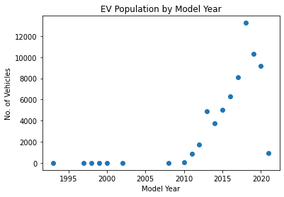

```python
#GIVE YOUR ANSWER FOR TASK-4 IN THIS CELL

plt.scatter(model_year.index, model_year)
plt.xlabel('Model Year')
plt.ylabel('No. of Vehicles')
plt.title('EV Population by Model Year')
```

Student Answer (Expected): The observation is the EV usage or purchase shown a general trend of exponential growth which might be slowed down in last couple of years due to COVID and other challenging situations.

Let's work towards plotting a histogram for 'MRSP Base Price' value of the entire EV Population database with the following two tasks.

```python
#GIVE YOUR ANSWER FOR TASK-5 IN THIS CELL

ev_pop_cleaned = ev_pop[(ev_pop['Base MSRP']>0) & (ev_pop['Base MSRP']<100000)]
```

**Task-6:** Plot the Histogram of the 'Base MSRP' series of the **ev_pop_cleaned** dataframe

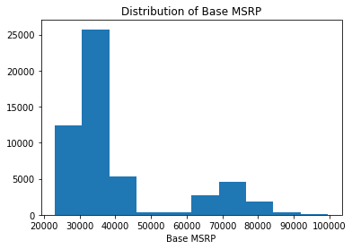

```python
#GIVE YOUR ANSWER FOR TASK-6 IN THIS CELL

plt.hist(ev_pop_cleaned['Base MSRP'])
plt.xlabel('Base MSRP')
plt.title('Distribution of Base MSRP')
```

**Exercise-2: In this exercise, we shall visualize the data from the manufacturer's perspective through following four tasks"**

**(POINTS: 40 - each task in this exercise carries 10 points)**

**Task-1:** Using the **ev_pop** dataframe, extract the top ten makers of electric vehicles by the dataset. Print the names of the makers and their corresponding value counts (no. of vehicles by the maker). [Hint: Use the **value_counts()** and **nlargest()** functions in tendem to extract the series of top ten makers]

```python
#GIVE YOUR ANSWER FOR TASK-1 IN THIS CELL

maker = ev_pop['Make'].value_counts().nlargest(10)
print(maker)
```

```
TESLA         25880
NISSAN        11220
CHEVROLET      8382
FORD           3671
TOYOTA         2832
BMW            2626
KIA            2262
AUDI           1113
VOLKSWAGEN      971
HYUNDAI         880
Name: Make, dtype: int64
```

**Task-2:** Make a bar plot for the top ten makers and their vehicle counts in the **ev_pop** database. Use all the proper plotting practices for labels and title. For better readability make sure the x labels are rotated 90 degrees.

**Hint**: Use the xticks.rotation() function for the label rotation. Use pyplot.show() to avoid unwanted texts above the bar graph.

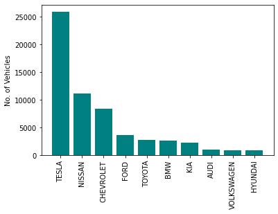

```python
#GIVE YOUR ANSWER FOR TASK-2 IN THIS CELL

plt.bar(maker.index, maker, color = 'teal')
plt.ylabel('No. of Vehicles')
plt.xticks(rotation = 90)
plt.show()
```

Now we want to observe the sales (revenue) trend of the top two manufacturers through the following tasks.

**Task-3:** Extract two separate dataframes for the top two manufacturers where the 'Make' column value of **ev_pop** matches with the manufacturer. Sort the two dataframes by the ascending values for 'Model Year' and save the two sorted dataframes as **sorted_Tesla** and **sorted_Nissan**. Apply the **groupby()** and **sum()** function together for grouping the sorted dataframes by 'Model Year' and get the summation for numerical fields. It will extract two dataframes (name them **tesla** and **nissan** respectively) which will provide the yearly sum of numerical columns like 'Electric Range' and 'Base MSRP'.

```python
#GIVE YOUR ANSWER FOR TASK-3 IN THIS CELL

ev_Tesla = ev_pop[ev_pop.Make == 'TESLA']
sorted_Tesla = ev_Tesla.sort_values('Model Year')

ev_Nissan = ev_pop[ev_pop.Make == 'NISSAN']
sorted_Nissan = ev_Nissan.sort_values('Model Year')

tesla = sorted_Tesla.groupby('Model Year').sum()
nissan = sorted_Nissan.groupby('Model Year').sum()
```

**Task-4:** Plot an overlaid line plot for 'Model Year' (vs.) 'Revenue (=summed up Base MSRP)' for each of the top two manufacturers. The plot must display an x-label, a y-label, a title, and a legend.

**Note-1:** To increase the line width of the line plot, use the argument **`lw`**. For example: lw = 3.

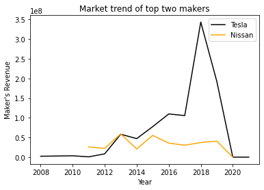

```python
#GIVE YOUR ANSWER FOR TASK-4 IN THIS CELL

plt.plot(tesla.index,tesla['Base MSRP'], color = 'black', label = 'Tesla')
plt.plot(nissan.index,nissan['Base MSRP'], color = 'orange', label = 'Nissan')
plt.xlabel('Year')
plt.ylabel('Maker\'s Revenue')
plt.title('Market trend of top two makers')
plt.legend()
```